# Reproducible Research: Peer Assessment 1

## Loading and preprocessing the data

Reading in activity csv file

```r
activity <- read.csv(unzip("activity.zip"))
```

## What is mean total number of steps taken per day?

Calculating total mean number of steps taken each day:

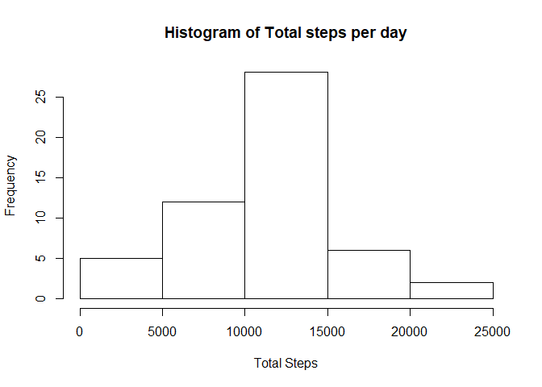

```r
total <- tapply(activity$steps, activity$date, sum)
hist(total, main = "Histogram of Total steps per day", xlab = "Total Steps")
```

```r
mean(total, na.rm = TRUE)
```

```
## [1] 10766.19
```

```r
median(total,na.rm = TRUE)
```

```
## [1] 10765
```

## What is the average daily activity pattern?

Using dplyr package to calculate mean steps per interval across all days:

```r
intervalmean <- activity %>% group_by(interval) %>% summarise(mean=mean(steps, na.rm = TRUE))
```

Plotting average number of steps per interval across all days using ggplot2 package

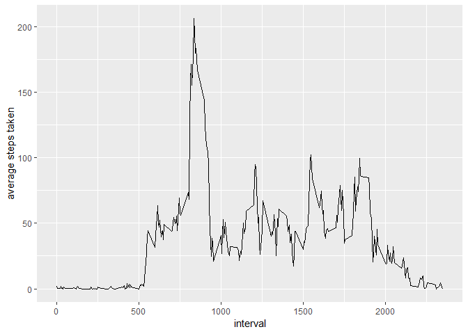

```r
ggplot(intervalmean, aes(interval, mean)) + geom_line() + ylab("average steps taken")
```

```r
which.max(intervalmean$mean)
```

```
## [1] 104
```

```r
intervalmean[104,]
```

```
## # A tibble: 1 x 2
##   interval  mean
##      <int> <dbl>
## 1      835  206.
```

The maximum average number of steps (206) occurs during the 104th 5 minute interval of the day which corresponds to 8.35am.

## Imputing missing values

Calculating total number of missing rows in dataset:

```r
sum(is.na(activity$steps))
```

```
## [1] 2304
```

From the above analysis we can see that 2304 measurements out of the total 17568 measurements in the sample are missing. This represents 13% of our dataset which is very high and can potentially have a significant impact on our analysis.

For this dataset we are going to impute all NA values with the mean for that interval.

Obtain a logical vector where NAs correspond to true:

```r
impute_values <- is.na(activity$steps)
```

Create a repeating vector of interval means to fill our missing data:

```r
impute_mean <- rep(intervalmean[["mean"]],8)
```

Note that we repeat the interval mean vector 8 times corresponding to 8 missing dates in the dataset. Complete our missing data:

```r
activity_complete <- activity
activity_complete$steps[impute_values] <- impute_mean
```

Calculating total number of steps taken per day with our complete dataset:

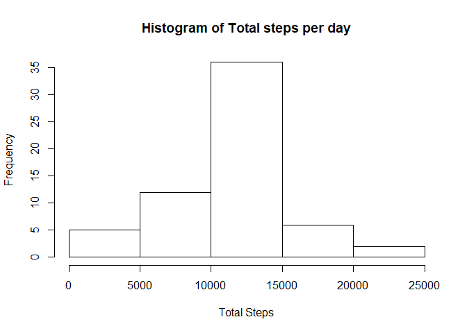

```r
total_complete <- tapply(activity_complete$steps, activity$date, sum)
hist(total_complete, main = "Histogram of Total steps per day", xlab = "Total Steps")
```

```r
mean(total_complete, na.rm = TRUE)
```

```
## [1] 10766.19
```

```r
median(total_complete,na.rm = TRUE)
```

```
## [1] 10766.19
```

## Are there differences in activity patterns between weekdays and weekends?

Converting date variable from factor to date format using the lubridate package:

```r
activity_complete$date <- ymd(activity_complete$date)
```

Use weekdays() function to find day of the week and then add a two level weekend/weekday factor variable to our data frame:

```r
DayoftheWeek <- weekdays(activity_complete$date)
weekendlogical <- DayoftheWeek %in% c("Saturday", "Sunday")
activity_complete$weekendweekday <- factor(ifelse(weekendlogical==TRUE, "weekend", "weekday"))
```

Making our panel plot showing showing 5-minute intervals on the x-axis and average steps taken over all weekend days or weekday days.

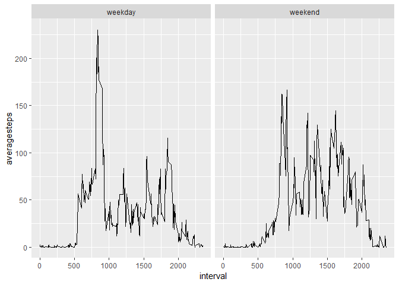

```r
plotdata <- aggregate(activity_complete$steps, list(activity_complete$interval, activity_complete$weekendweekday), mean)
names(plotdata) <- c("interval", "weekendweekday", "averagesteps")
p <- ggplot(data = plotdata, aes(x = interval, y = averagesteps)) + geom_line()
p + facet_wrap(~weekendweekday)
```